# Topic 7

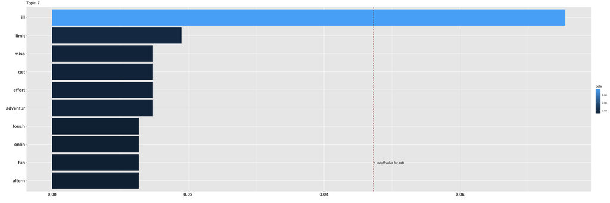

On interpreting beta: the term has a beta probability of being generated from the particular topic.

Values below are gamma : An estimated proportion of words from that document that are generated from that topic.

**Text Record Number: 117** gamma: 12 % likelihood of this document (based on its words) in this topic

**First I got Casio CT-S300 (61 key) to see if I can stick to it. Few months later bought Roland FP-30X (88keys), sold CT-S300 and just recently got CASIO CT-S1 (61 keys). Why? I wanted to have a portable keyboard so I could take it with me when traveling somewhere and not to miss my daily practice. CT-S1 has fewer features compared to CT-S300 but it has a better sound engine.**

**Text Record Number: 908** gamma: 12 % likelihood of this document (based on its words) in this topic

**An alternative is buying an electronic keyboard on a stand. Some reproduce the touch and feel pretty well, more reproduce the sound pretty well, and you can get either the full 88 keys or a more transportable fewer keys. These you can learn to play on until you decide whether you like it, and whether you want to go for a real piano. They cost less than $1000 USD even for a pretty decent one, and a few hundred for a not so decent one. Easy to get rid of too, and even if you keep it they take up very little space with the stand folded up.**

**Text Record Number: 1097** gamma: 12 % likelihood of this document (based on its words) in this topic

**Awesome goal! You can definitely start a routine or tune on mobile. Can you let me know where you’re getting stuck? Can email screenshots to tuneupgrade@gmail.com**

**Text Record Number: 1216** gamma: 12 % likelihood of this document (based on its words) in this topic

** i really want to play Marriage D’ Amour. But i have problems with the hand independence.

I can play Nocturne Op 9 No 2 (dropped, later I’ll pick it back up) and other overrated beginner piece such as Fur Elise and Moonlight Sonata 1st.

Is there any suitable hand independence practice for piece like Marriage D’ Amour?**

**Text Record Number: 1161** gamma: 12 % likelihood of this document (based on its words) in this topic

**Okay sounds good! I’ll be working on that, thank you so much for the critique!!**

**Text Record Number: 1334** gamma: 12 % likelihood of this document (based on its words) in this topic

**Hi guys! I’m a musician by profession (still in study) but as far as my piano skills go - I used to be pretty decent at it when I was a tween but I went through a pretty rough patch for 6-7 years during which I didn’t touch music, so all of that skill is pretty much nonexistent now.

Some of the things I enjoy doing are composing film score, and rhythm&blues. So often times very piano oriented. I’m a decent composer but I’m desperate for some exercises I can do intensively for a few months to regain my muscle memory with scales on the piano. I end up struggling to play most of the things I’ve composed and that to me is absolutely backwards.

I’ve looked up on YouTube and other sources but everything is just all over the place. I struggle to pick the right exercise because I’m definitely not a complete beginner, but I have lost a considerable amount of my muscle memory.

Can you help me with some suggestions? Thank you!**

**Text Record Number: 894** gamma: 12 % likelihood of this document (based on its words) in this topic

**Learning hands apart has a very specific purpose when you are still new to learning music theory. The point of doing that is to isolate the melody from the harmony. It’s easier to understand how these two layers are interacting with one another when you run through them one layer at a time, and it becomes even easier to understand when you run through it *slowly*, hands together. Additionally, it’s easier to play hands together when you know what your “anchor” notes are. That is to say, certain notes will happen at the same time in both hands, and others will not. Knowing where these anchors are makes it a lot easier to get used to playing it hands together.

Your teacher is also 100% correct about the muscle memory aspect. Every once in awhile I’ll try to noodle around and play a little bit of something I tried to learn months ago. I’ll remember the notes, but I won’t quite have the right rhythm to it. Then I feel around in my brain for a few minutes until suddenly it hits me, and then I’m back to playing it like I never even forgot what it sounded like. Once that muscle memory is there, it’s going to be there for a very long time. You might just need a little bit of something to jog your cognitive memory for it, that’s all.

He is also absolutely correct about how to practice sightreading. It is *SO MUCH EASIER* to read music when you aren’t slowly and methodically working through a piece, one singular note at a time, trying to decrypt the ancient cuneiform that lays before you, trying to keep track of what your fingers and hands are doing all the time. Once it’s committed to muscle memory, you can work on paying attention to the sheets. You will begin to associate the note on the sheet with what it “feels” like on the piano, if that makes sense. Think about how you learned how to type on a computer keyboard. This is a process that is extremely slow going at first, but eventually you hit a point where you just instinctively know where your fingers are, without having to look at them at all. Reading sheet music kinda works in this regard too. Sheet music is pretty different in some ways though. Someone who is really good at sightreading isn’t looking at it note for note, they’re looking at entire sections and digesting it chunk by chunk. However, that “you get used to how certain notes feel” thing still applies. Computer keyboards use home row to tell you how your fingers need to work. Piano sheets use key signatures.**